# Exercises

```python
import matplotlib.pyplot as plt
from nltk.book import sent1, sent3, text2, text4, text5

import seaborn as sns

sns.set()
%matplotlib inline
```

```
*** Introductory Examples for the NLTK Book ***
Loading text1, ..., text9 and sent1, ..., sent9
Type the name of the text or sentence to view it.
Type: 'texts()' or 'sents()' to list the materials.
text1: Moby Dick by Herman Melville 1851
text2: Sense and Sensibility by Jane Austen 1811
text3: The Book of Genesis
text4: Inaugural Address Corpus
text5: Chat Corpus
text6: Monty Python and the Holy Grail
text7: Wall Street Journal
text8: Personals Corpus
text9: The Man Who Was Thursday by G . K . Chesterton 1908
```

### 1. Try using the Python interpreter as a calculator, and typing expressions like `12 / (4 + 1)`.

```python
12 / (4 + 1)
```

```
2.4
```

### 2. Given an alphabet of 26 letters, there are 26 to the power 10, or `26 ** 10`, ten-letter strings we can form. That works out to `141167095653376`. How many hundred-letter strings are possible?

```python
26 ** 100
```

```
3142930641582938830174357788501626427282669988762475256374173175398995908420104023465432599069702289330964075081611719197835869803511992549376
```

### 3. The Python multiplication operation can be applied to lists. What happens when you type `['Monty', 'Python'] * 20`, or `3 * sent1`?

```python
['Monty', 'Python'] * 20
```

```
['Monty',
 'Python',
 'Monty',
 'Python',
 'Monty',
 'Python',
 'Monty',
 'Python',
 'Monty',
 'Python',
 'Monty',
 'Python',
 'Monty',
 'Python',
 'Monty',
 'Python',
 'Monty',
 'Python',
 'Monty',
 'Python',
 'Monty',
 'Python',
 'Monty',
 'Python',
 'Monty',
 'Python',
 'Monty',
 'Python',
 'Monty',
 'Python',
 'Monty',
 'Python',
 'Monty',
 'Python',
 'Monty',
 'Python',
 'Monty',
 'Python',
 'Monty',
 'Python']
```

```python
3 * sent1
```

```
['Call',
 'me',
 'Ishmael',
 '.',
 'Call',
 'me',
 'Ishmael',
 '.',
 'Call',
 'me',
 'Ishmael',
 '.']
```

### 4. Review [1](https://www.nltk.org/book/ch01.html#sec-computing-with-language-texts-and-words) on computing with language. How many words are there in `text2`? How many distinct words are there?

```python
len(text2)
```

```
141576
```

```python
len(set(text2))
```

```
6833
```

### 5. Compare the lexical diversity scores for humor and romance fiction in [1.1](https://www.nltk.org/book/ch01.html#tab-brown-types). Which genre is more lexically diverse?

Humor.

### 6. Produce a dispersion plot of the four main protagonists in Sense and Sensibility: Elinor, Marianne, Edward, and Willoughby. What can you observe about the different roles played by the males and females in this novel? Can you identify the couples?

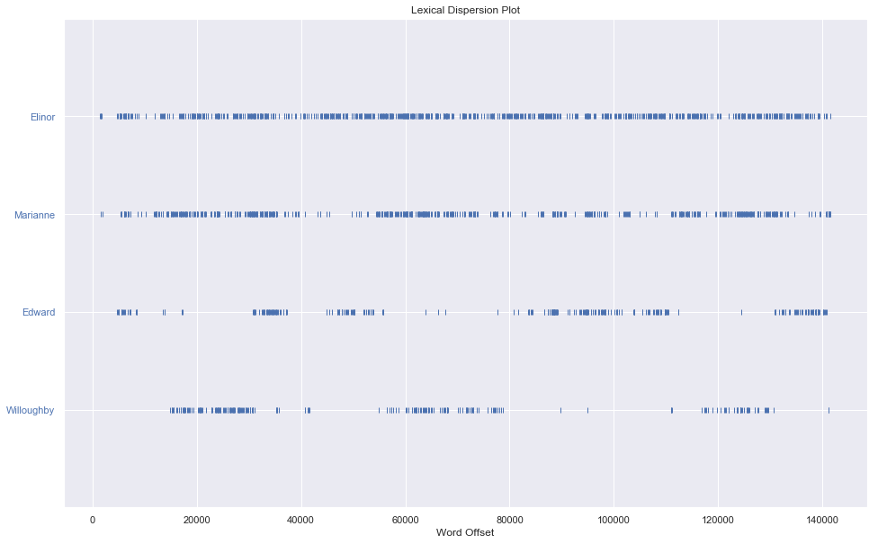

```python
plt.figure(figsize=(16,10))

text2.dispersion_plot(["Elinor", "Marianne", "Edward", "Willoughby"])
```

Out of 4 protagonists, it seem that Elinor and Marianne are the much more main in the story than Edward and Willoughby. It is hard to identify the couples from the dispersion plot.

### 7. Find the collocations in `text5`.

```python
text5.collocations()
```

```
wanna chat; PART JOIN; MODE #14-19teens; JOIN PART; PART PART;
cute.-ass MP3; MP3 player; JOIN JOIN; times .. .; ACTION watches; guys
wanna; song lasts; last night; ACTION sits; -...)...- S.M.R.; Lime
Player; Player 12%; dont know; lez gurls; long time
```

### 8. Consider the following Python expression: `len(set(text4))`. State the purpose of this expression. Describe the two steps involved in performing this computation.

```python
len(set(text4))
```

```
9754
```

This expression computes the number of distinct words that appear in `text4`. The `set` function first creates a collection of distinct words in the text and then the `len` function outputs the number of distinct words.

### 9. Review [2](https://www.nltk.org/book/ch01.html#sec-a-closer-look-at-python-texts-as-lists-of-words) on lists and strings.

### a. Define a string and assign it to a variable, e.g., `my_string = 'My String'` (but put something more interesting in the string). Print the contents of this variable in two ways, first by simply typing the variable name and pressing enter, then by using the `print` statement.

```python
my_string = "Today is Friday."

my_string
```

```
'Today is Friday.'
```

```python
print(my_string)
```

```
Today is Friday.
```

### b. Try adding the string to itself using `my_string + my_string`, or multiplying it by a number, e.g., `my_string * 3`. Notice that the strings are joined together without any spaces. How could you fix this?

```python
my_string + ' ' + my_string
```

```
'Today is Friday. Today is Friday.'
```

### 10. Define a variable `my_sent` to be a list of words, using the syntax `my_sent = ["My", "sent"]` (but with your own words, or a favorite saying).

### a. Use `' '.join(my_sent)` to convert this into a string.

```python
my_sent = ["My", "sent"]
my_sent = ' '.join(my_sent)

my_sent
```

```
'My sent'
```

### b. Use `split()` to split the string back into the list form you had to start with.

```python
my_sent = my_sent.split()

my_sent
```

```
['My', 'sent']
```

### 11. Define several variables containing lists of words, e.g., `phrase1`, `phrase2`, and so on. Join them together in various combinations (using the plus operator) to form whole sentences. What is the relationship between `len(phrase1 + phrase2)` and `len(phrase1) + len(phrase2)`?

```python
phrase1 = ["Today", "is", "Monday", "."]
phrase2 = ["Tomorrow", "is", "Tuesday", "."]
```

```python
phrase1 + phrase2
```

```
['Today', 'is', 'Monday', '.', 'Tomorrow', 'is', 'Tuesday', '.']
```

```python
phrase2 + phrase2
```

```
['Tomorrow', 'is', 'Tuesday', '.', 'Tomorrow', 'is', 'Tuesday', '.']
```

```python
len(phrase1 + phrase2)
```

```
8
```

```python
len(phrase1) + len(phrase2)
```

```
8
```

`len(phrase1 + phrase2)` and `len(phrase1) + len(phrase2)` are equal.

### 12. Consider the following two expressions, which have the same value. Which one will typically be more relevant in NLP? Why?

a. `"Monty Python"[6:12]`  
b. `["Monty", "Python"][1]`

`b` is more relevant in NLP since a minimal unit of text data is a word. For `a`, one has to detect and identify the start and end indexes every time to choose a word from text.

### 13. We have seen how to represent a sentence as a list of words, where each word is a sequence of characters. What does `sent1[2][2]` do? Why? Experiment with other index values.

`sent1[2][2]` returns the third letter of the third word of `sent1`.

### 14. The first sentence of `text3` is provided to you in the variable `sent3`. The index of `the` in `sent3` is `1`, because `sent3[1]` gives us 'the'. What are the indexes of the two other occurrences of this word in `sent3`?

```python
[index for index, word in enumerate(sent3) if word == "the" and index != 1]
```

```
[5, 8]
```

### 15. Review the discussion of conditionals in [4](https://www.nltk.org/book/ch01.html#sec-making-decisions). Find all words in the Chat Corpus (`text5`) starting with the letter `b`. Show them in alphabetical order.

```python
sorted(set([word for word in text5 if word.startswith("b")]))
```

```
['b',
 'b-day',
 'b/c',
 'b4',
 'babay',
 'babble',
 'babblein',
 'babe',
 'babes',
 'babi',
 'babies',
 'babiess',
 'baby',
 'babycakeses',
 'bachelorette',
 'back',
 'backatchya',
 'backfrontsidewaysandallaroundtheworld',
 'backroom',
 'backup',
 'bacl',
 'bad',
 'bag',
 'bagel',
 'bagels',
 'bahahahaa',
 'bak',
 'baked',
 'balad',
 'balance',
 'balck',
 'ball',
 'ballin',
 'balls',
 'ban',
 'band',
 'bandito',
 'bandsaw',
 'banjoes',
 'banned',
```

[output cut: 253 more lines]

```
 'butter',
 'butterscotch',
 'button',
 'buttons',
 'buy',
 'buying',
 'bwahahahahahahahahahaha',
 'by',
 'byb',
 'bye',
 'byeee',
 'byeeee',
 'byeeeeeeee',
 'byeeeeeeeeeeeee',
 'byes']
```